# Project 3

**Group members: Fabiana Latorre, Oliver Benton Javier, Ernesto Canales, and Nikolaj Plagborg-Moller.**

Our datasets can be found at: ‘http://catalog.data.gov/dataset/international-food-security’, ‘http://catalog.data.gov/dataset/annual-electricity-generation-1980-2009-dff2e’, ‘http://data.un.org/Data.aspx?q=GNI+Country&d=SOWC&f=inID%3a94’, ‘http://visualizing.org/sites/default/files/data_set/Marc%20Schwartz/HDR_2010_dataset.zip’, ‘http://www.facebook.com/l.php?u=http%3A%2F%2Fdata.worldbank.org%2Fabout%2Fcountry-and-lending-groups&h=0AQHX1bNI’.

Since our data is listed by country, there are not thousands of rows in every data set. We asked in class if this was okay and had it approved.

We load the data-tables into the corresponding variables, food (for food security data), electricity (for electricity generation data), GNI (for gross national income data), HDI (for human development index data), income (for income categorical data), and display a subset of each data set.

```r
source('../01 Data/Fetching_Data.R', echo=TRUE)
```

```
##
## > food <- data.frame(fromJSON(getURL(URLencode("129.152.144.84:5001/rest/native/?query=\"select * from FoodSecurity\""),
## +     httpheader = c(DB = "j ..." ... [TRUNCATED]
##
## > electricity <- data.frame(fromJSON(getURL(URLencode("129.152.144.84:5001/rest/native/?query=\"select * from Electricity\""),
## +     httpheader = c(D .... [TRUNCATED]
##
## > GNI <- data.frame(fromJSON(getURL(URLencode("129.152.144.84:5001/rest/native/?query=\"select * from GNI\""),
## +     httpheader = c(DB = "jdbc:oracle ..." ... [TRUNCATED]
##
## > HDI <- data.frame(eval(parse(text = substring(getURL(URLencode("http://129.152.144.84:5001/rest/native/?query=\"select * from HDI\""),
## +     httphe .... [TRUNCATED]
##
## > income <- data.frame(eval(parse(text = substring(getURL(URLencode("http://129.152.144.84:5001/rest/native/?query=\"select * from INCOME\""),
## +      .... [TRUNCATED]
##
## > food %>% tbl_df
## Source: local data frame [52,335 x 6]
##
##    COUNTRY            COMMODITY
## 1  Algeria Total Grains/Cereals
## 2  Algeria        Economic Data
## 3  Algeria        Economic Data
## 4  Algeria        Economic Data
## 5  Algeria        Economic Data
## 6  Algeria        Economic Data
## 7  Algeria Total Grains/Cereals
## 8  Algeria Total Grains/Cereals
## 9  Algeria Total Grains/Cereals
## 10 Algeria Total Grains/Cereals
## ..     ...                  ...
## Variables not shown: ITEM (fctr), UNIT (fctr), YEAR (int), AMOUNT (int)
##
## > electricity %>% tbl_df
## Source: local data frame [232 x 31]
##
##          Country              X1980              X1981              X1982
## 1         France   250.518005371094   261.884002685547   264.531005859375
## 2        Germany                 --                 --                 --
## 3  Germany, East   98.8079986572266   94.4779968261719   96.5199966430664
```

[output cut: 59 more lines]

```
## > income %>% tbl_df
## Source: local data frame [210 x 3]
##
##              COUNTRY                 REGION             INCOME
## 1            Albania                 Europe  Uppermiddleincome
## 2            Algeria MiddleEast&NorthAfrica  Uppermiddleincome
## 3      AmericanSamoa               EastAsia  Uppermiddleincome
## 4            Andorra                     .. Highincome:nonOECD
## 5             Angola      Sub-SaharanAfrica  Uppermiddleincome
## 6  AntiguaandBarbuda                     .. Highincome:nonOECD
## 7          Argentina           LatinAmerica  Uppermiddleincome
## 8            Armenia                 Europe  Lowermiddleincome
## 9              Aruba                     .. Highincome:nonOECD
## 10         Australia                     ..    Highincome:OECD
## ..               ...                    ...                ...
```

We modify (wrangle) the food security data, so that we only have the population numbers in millions for each country for the year 2005. Furthermore, 2005 is also selected from the electricity generation data, and the columns of both datasets are renamed appropriately. The two resulting tables are joined using an inner join on the “Country” column and we display a subset of the resulting table below.

```r
source('../02 Data Wrangling/Wrangling1.R', echo=TRUE)
```

```
##
## > foodwrang <- food %>% filter(YEAR == 2005, COMMODITY ==
## +     "Population") %>% select(COUNTRY, AMOUNT) %>% arrange(COUNTRY)
##
## > colnames(foodwrang) <- c("Country", "Population")
##
## > electricitywrang <- electricity %>% select(Country,
## +     X2005)
##
## > colnames(electricitywrang) <- c("Country", "ElectricityGeneration")
##
## > joined_data <- inner_join(foodwrang, electricitywrang,
## +     by = "Country")
```

```
##
## > joined_data %>% tbl_df
## Source: local data frame [39 x 3]
##
##    Country Population ElectricityGeneration
## 1  Algeria         33      31.9069995880127
## 2   Angola         16      2.58500003814697
## 3  Armenia          3      5.97703981399536
## 4    Benin          8     0.101000003516674
## 5  Bolivia          9      4.89376020431519
## 6  Burundi          7     0.101000003516674
## 7     Chad         10    0.0939999967813492
## 8  Ecuador         13      12.9809999465942
## 9    Egypt         74      102.805999755859
## 10 Eritrea          4     0.270999997854233
## ..     ...        ...                   ...
```

We chose to plot generated electricity versus population and have country name as the legend. Since there are many countries in our joined data frame, the legend would be very long, so we filtered out countries that have an electricity production above 50 billion kilowatthours. Furthermore we formatted the colors, axis, and title of the plot.

```r
source('../03 Visualizations/Visualization1.R', echo=TRUE)
```

```
##
## > bottom_el_joined <- joined_data %>% filter(as.numeric(ElectricityGeneration) <
## +     50)
##
## > g <- ggplot(bottom_el_joined, aes(x = Population,
## +     y = as.numeric(ElectricityGeneration), color = Country)) +
## +     geom_point()
##
## > g + labs(title = "Electricity Generation versus Population Size Year 2005") +
## +     theme(plot.title = element_text(size = 15, face = "bold",
## +    .... [TRUNCATED]
```

[figure not shown]

From this subset of the data at the bottom of the electricity production scale, there appears to be no meaningful correlation between population size and the amount of generated electricity.

For our second data wrangling we use information about gross national income. First we assign a variable to the worflow so that we can access it later. Next we used the select and filter functions to narrow down the criteria to seven countries and the year 2011. After we used the distinct function to remove any duplicate rows. Next, we assigned another variable for our joined data set. Then we used the select and filter functions to narrow down the criteria to six countries and the year 2011. Next we used the full_join function to combine both data sets by country and year. Lastly we used the distinct function to remove any duplicate rows.

```r
source('../02 Data Wrangling/Wrangling2.R', echo=TRUE)
```

```
##
## > CTYR <- food %>% select(COUNTRY, YEAR) %>% filter(COUNTRY ==
## +     "Algeria" | COUNTRY == "Burundi" | COUNTRY == "Lesotho" |
## +     COUNTRY == "Ken ..." ... [TRUNCATED]
##
## > GNIJ <- GNI %>% select(COUNTRY, YEAR, UNIT, VALUE) %>%
## +     filter(COUNTRY == "Algeria" | COUNTRY == "Burundi" | COUNTRY ==
## +         "Kenya" | C .... [TRUNCATED]
```

```
##
## > GNIJ %>% tbl_df
## Source: local data frame [7 x 4]
##
##   COUNTRY YEAR UNIT VALUE
## 1 Algeria 2011  US$  4470
## 2  Angola 2011  US$  4060
## 3 Burundi 2011  US$   250
## 4    Chad 2011  US$   690
## 5   Ghana 2011  US$  1410
## 6   Kenya 2011  US$   820
## 7 Lesotho 2011   NA    NA
```

In order to make the visualization for gross national income, we assigned country names as the x-axis values and amount in US dollars as the y value. Then we used the geom_bar function to create a bar graph of the data. Next we formatted the axis labels, theme, text vertical orientation, adjusted position, and changed the background color.

```r
source('../03 Visualizations/Visualization2.R', echo=TRUE)
```

```
##
## > g <- ggplot(GNIJ, aes(x = COUNTRY, y = VALUE)) + geom_bar(stat = "identity")
##
## > g + ggtitle("Gross National Income") + theme(plot.title = element_text(size = 20,
## +     face = "bold", vjust = 2)) + labs(x = "Country", y = "US Do ..." ... [TRUNCATED]
```

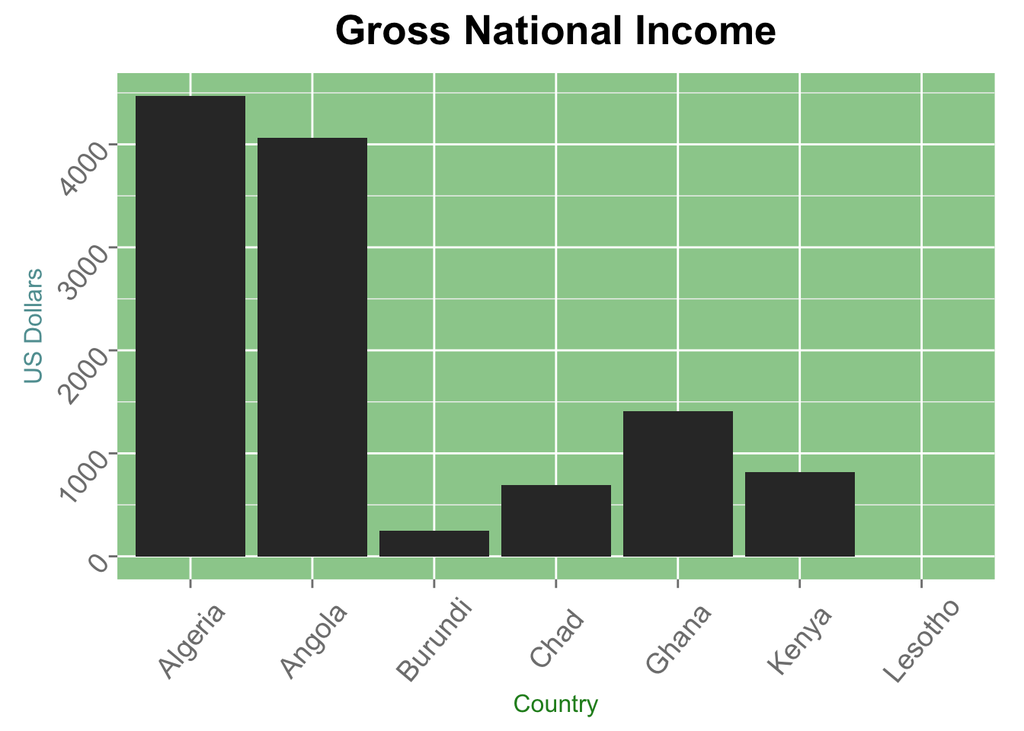

We implemented a full join to combine both data sets because we wanted to include the 7 countries that are in the first dataset along with the 6 countries that are in the second dataset. After visualizing the output, it makes sense that one of the countries, Lesotho, is missing information since the full join did not find a match for this record.

```r
source('../02 Data Wrangling/Wrangling3.R', echo=TRUE)
```

```
##
## > food_aid <- food %>% select(COUNTRY, COMMODITY, ITEM,
## +     AMOUNT, YEAR) %>% filter(ITEM == "Total", COMMODITY == "Food Aid",
## +     YEAR == "2000 ..." ... [TRUNCATED]
##
## > food_aid <- food_aid %>% spread(YEAR, AMOUNT)
##
## > colnames(food_aid) <- c("COUNTRY", "COMMODITY", "ITEM",
## +     "food_aid2000", "food_aid2008")
##
## > FOODAID2000 <- food_aid %>% select(food_aid2000)
##
## > FOODAID2008 <- food_aid %>% select(food_aid2008)
##
## > net_savings <- HDI %>% select(1, NETSAVINGS2000, NETSAVINGS2008) %>%
## +     filter(COLUMN1 == "Egypt" | COLUMN1 == "Angola" | COLUMN1 ==
## +          .... [TRUNCATED]
##
## > savings <- bind_cols(net_savings, FOODAID2000, FOODAID2008)
##
## > colnames(savings) <- c("Country", "NETSAVINGS2000",
## +     "NETSAVINGS2008", "FOODAID2000", "FOODAID2008")
##
## > savings %>% tbl_df
## Source: local data frame [5 x 5]
##
##   Country    NETSAVINGS2000    NETSAVINGS2008 FOODAID2000 FOODAID2008
## 1 Ecuador  2.40000009536743 0.400000005960464         344           0
## 2   Egypt               8.5  2.09999990463257          55           3
## 3 Morocco  18.7999992370605  19.7999992370605          35           6
## 4    Peru  7.40000009536743                 7         259           0
## 5  Angola -32.7999992370605 -42.5999984741211         288           9
```

We then created two separate graphs for 2000 and 2008 data and joined them using pushViewport(). The scaling in the x axis was formatted to match both graphs.

```r
source('../03 Visualizations/Visualization3.R', echo=TRUE)
```

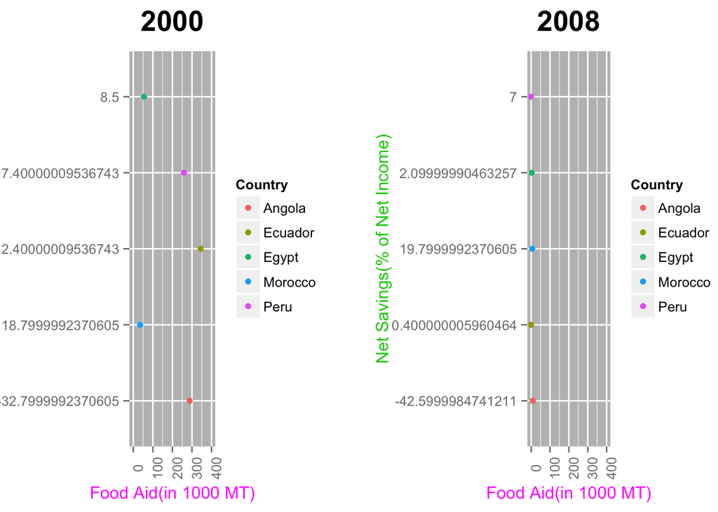

```
##
## > first <- ggplot(savings, aes(x = FOODAID2000, y = NETSAVINGS2000,
## +     color = Country)) + geom_point()
##
## > second <- ggplot(savings, aes(x = FOODAID2008, y = NETSAVINGS2008,
## +     color = Country)) + geom_point()
##
## > first <- first + ggtitle("2000")
##
## > first <- first + theme(plot.title = element_text(size = 20,
## +     face = "bold", vjust = 2))
##
## > second <- second + ggtitle("2008")
##
## > second <- second + theme(plot.title = element_text(size = 20,
## +     face = "bold", vjust = 2))
##
## > first <- first + labs(x = "Food Aid(in 1000 MT)",
## +     y = "Net Savings(% of Net Income)")
##
## > second <- second + labs(x = "Food Aid(in 1000 MT)",
## +     y = "Net Savings(% of Net Income)")
##
## > first <- first + theme(axis.title.x = element_text(color = "150",
## +     vjust = 0.35), axis.title.y = element_text(color = "139",
## +     vjust = 0. .... [TRUNCATED]
##
## > second <- second + theme(axis.title.x = element_text(color = "150",
## +     vjust = 0.35), axis.title.y = element_text(color = "139",
## +     vjust =  .... [TRUNCATED]
##
## > first <- first + xlim(c(0, 400))
##
## > second <- second + xlim(c(0, 400))
##
## > first <- first + theme(panel.background = element_rect(fill = "gray"))
##
## > first <- first + theme(plot.background = element_rect(fill = "white"),
## +     axis.text.x = element_text(angle = 90))
##
## > second <- second + theme(panel.background = element_rect(fill = "gray"))
##
## > second <- second + theme(plot.background = element_rect(fill = "white"),
## +     axis.text.x = element_text(angle = 90))
##
## > library(grid)
##
## > pushViewport(viewport(layout = grid.layout(1, 2),
## +     width = 1.1))
##
## > print(first, vp = viewport(layout.pos.row = 1, layout.pos.col = 1))
##
## > print(second, vp = viewport(layout.pos.row = 1, layout.pos.col = 2))
```

We concluded from looking at the graphs that in 2000, countries with the least Saving Rates received the most amount of food aid. In 2008, however we saw a dramatic decrease of Food Aid for ALL countries, therefore indicating that either food aid is becoming less popular or countries are quickly developing into independent nations that do not require aid anymore.

```r
source('../03 Visualizations/Categoricals.R', echo=FALSE)
```

[figure not shown]

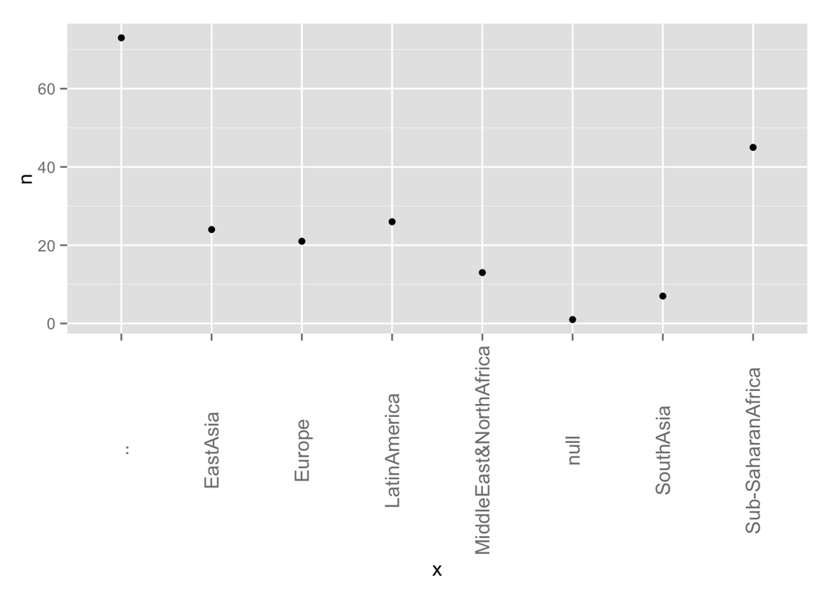

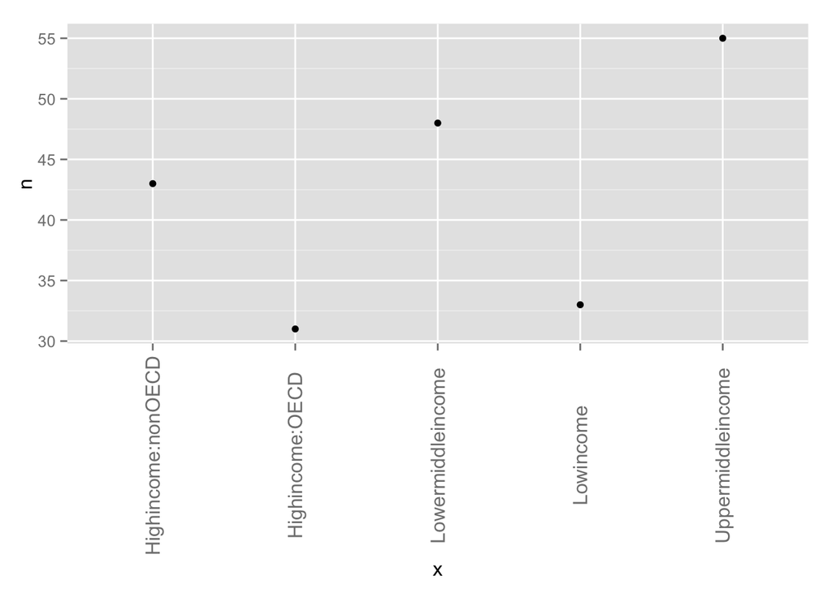

Here is our png-file.

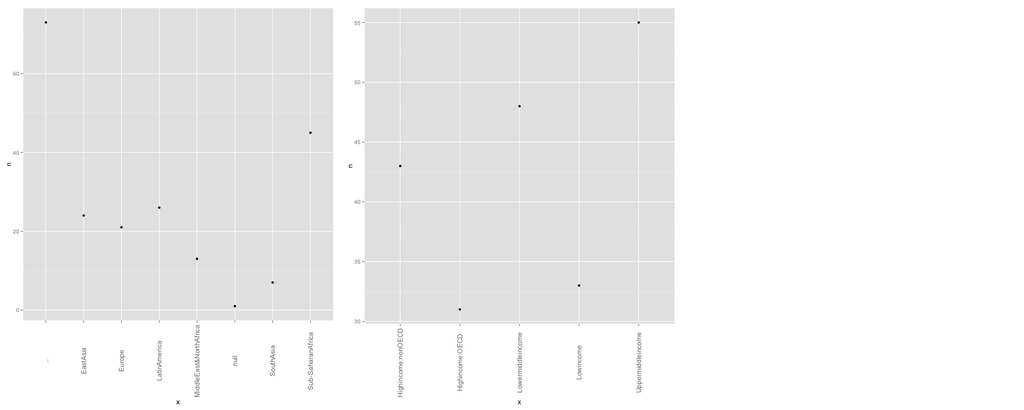